# Udacity DAND Project 2 - Investigate a dataset

- Introduction
- Data Wrangling
- Exploratory Data Analysis
- Conclusions

## Introduction

The selected dataset has information about 100k medical appointments in Brazil that shows whether a patient showed up to his/her appointment as well as multiple other factors that may affect their showing up. Namely, it provides with each record the following info: PatientId, AppointmentID, Gender, ScheduledDay, AppointmentDay, Age, Neighbourhood, Scholarship, Hipertension, Diabetes, Alcoholism, Handcap, SMS_received, No-show.

```python
# importing statements for all of the needed packages

import numpy as np
import pandas as pd
import matplotlib.pyplot as plt
import seaborn as sns
%matplotlib inline
```

## Data Wrangling

In this section of the report, we will load in the data, check for cleanliness, and then trim and clean the dataset for analysis.

### General Properties

```python
# Loading data and printing out a few lines.
df = pd.read_csv('noshowappointments.csv')
df.head()
```

|  | PatientId | AppointmentID | Gender | ScheduledDay | AppointmentDay | Age | Neighbourhood | Scholarship | Hipertension | Diabetes | Alcoholism | Handcap | SMS_received | No-show |
| --- | --- | --- | --- | --- | --- | --- | --- | --- | --- | --- | --- | --- | --- | --- |
| 0 | 2.987250e+13 | 5642903 | F | 2016-04-29T18:38:08Z | 2016-04-29T00:00:00Z | 62 | JARDIM DA PENHA | 0 | 1 | 0 | 0 | 0 | 0 | No |
| 1 | 5.589978e+14 | 5642503 | M | 2016-04-29T16:08:27Z | 2016-04-29T00:00:00Z | 56 | JARDIM DA PENHA | 0 | 0 | 0 | 0 | 0 | 0 | No |
| 2 | 4.262962e+12 | 5642549 | F | 2016-04-29T16:19:04Z | 2016-04-29T00:00:00Z | 62 | MATA DA PRAIA | 0 | 0 | 0 | 0 | 0 | 0 | No |
| 3 | 8.679512e+11 | 5642828 | F | 2016-04-29T17:29:31Z | 2016-04-29T00:00:00Z | 8 | PONTAL DE CAMBURI | 0 | 0 | 0 | 0 | 0 | 0 | No |
| 4 | 8.841186e+12 | 5642494 | F | 2016-04-29T16:07:23Z | 2016-04-29T00:00:00Z | 56 | JARDIM DA PENHA | 0 | 1 | 1 | 0 | 0 | 0 | No |

```python
df.shape
```

```
(110527, 14)
```

We have 110527 rows and 14 columns.

```python
df.describe()
```

|  | PatientId | AppointmentID | Age | Scholarship | Hipertension | Diabetes | Alcoholism | Handcap | SMS_received |
| --- | --- | --- | --- | --- | --- | --- | --- | --- | --- |
| count | 1.105270e+05 | 1.105270e+05 | 110527.000000 | 110527.000000 | 110527.000000 | 110527.000000 | 110527.000000 | 110527.000000 | 110527.000000 |
| mean | 1.474963e+14 | 5.675305e+06 | 37.088874 | 0.098266 | 0.197246 | 0.071865 | 0.030400 | 0.022248 | 0.321026 |
| std | 2.560949e+14 | 7.129575e+04 | 23.110205 | 0.297675 | 0.397921 | 0.258265 | 0.171686 | 0.161543 | 0.466873 |
| min | 3.921784e+04 | 5.030230e+06 | -1.000000 | 0.000000 | 0.000000 | 0.000000 | 0.000000 | 0.000000 | 0.000000 |
| 25% | 4.172614e+12 | 5.640286e+06 | 18.000000 | 0.000000 | 0.000000 | 0.000000 | 0.000000 | 0.000000 | 0.000000 |
| 50% | 3.173184e+13 | 5.680573e+06 | 37.000000 | 0.000000 | 0.000000 | 0.000000 | 0.000000 | 0.000000 | 0.000000 |
| 75% | 9.439172e+13 | 5.725524e+06 | 55.000000 | 0.000000 | 0.000000 | 0.000000 | 0.000000 | 0.000000 | 1.000000 |
| max | 9.999816e+14 | 5.790484e+06 | 115.000000 | 1.000000 | 1.000000 | 1.000000 | 1.000000 | 4.000000 | 1.000000 |

Above table shows descriptive statistics about each column, the following can be observed:

- Average age for patients is 37 years old with min -1 (meaning we have some invalid age data) and a max of 115 years old, where most of the patients are between 18 and 55 years old.
- 9% of patients have scholership.
- 20% of patients have hypertension.
- 7% of patients have diabetes.
- 3% of patients have alcoholism.
- 2% of patients are handicapped.
- 32% of patients have received SMS about their appointments.

```python
df.info()
```

```
<class 'pandas.core.frame.DataFrame'>
RangeIndex: 110527 entries, 0 to 110526
Data columns (total 14 columns):
PatientId         110527 non-null float64
AppointmentID     110527 non-null int64
Gender            110527 non-null object
ScheduledDay      110527 non-null object
AppointmentDay    110527 non-null object
Age               110527 non-null int64
Neighbourhood     110527 non-null object
Scholarship       110527 non-null int64
Hipertension      110527 non-null int64
Diabetes          110527 non-null int64
Alcoholism        110527 non-null int64
Handcap           110527 non-null int64
SMS_received      110527 non-null int64
No-show           110527 non-null object
dtypes: float64(1), int64(8), object(5)
memory usage: 11.8+ MB
```

No missing values in any columns, however, multiple cleaning operations can be applied (stated in the next section).

### Data Cleaning

After basic exploring of the dataset, the following can be applied to clean the data and make it ready for analysis:

- Some columns will be dropped since they don't have a use in the analysis, such as PatientId, AppointmentID.
- There are some age records with negative values, so we will solve that by filling them with the mean.
- No-show column will be changed from Yes and No to 1 and 0 to make it easier to perform numerical operations.

Starting with dropping not usefull columns

```python
df.drop(['PatientId', 'AppointmentID'], axis=1, inplace=True)
df.head()
```

|  | Gender | ScheduledDay | AppointmentDay | Age | Neighbourhood | Scholarship | Hipertension | Diabetes | Alcoholism | Handcap | SMS_received | No-show |
| --- | --- | --- | --- | --- | --- | --- | --- | --- | --- | --- | --- | --- |
| 0 | F | 2016-04-29T18:38:08Z | 2016-04-29T00:00:00Z | 62 | JARDIM DA PENHA | 0 | 1 | 0 | 0 | 0 | 0 | No |
| 1 | M | 2016-04-29T16:08:27Z | 2016-04-29T00:00:00Z | 56 | JARDIM DA PENHA | 0 | 0 | 0 | 0 | 0 | 0 | No |
| 2 | F | 2016-04-29T16:19:04Z | 2016-04-29T00:00:00Z | 62 | MATA DA PRAIA | 0 | 0 | 0 | 0 | 0 | 0 | No |
| 3 | F | 2016-04-29T17:29:31Z | 2016-04-29T00:00:00Z | 8 | PONTAL DE CAMBURI | 0 | 0 | 0 | 0 | 0 | 0 | No |
| 4 | F | 2016-04-29T16:07:23Z | 2016-04-29T00:00:00Z | 56 | JARDIM DA PENHA | 0 | 1 | 1 | 0 | 0 | 0 | No |

Then, will slove the age column issue, finding out how many records with age <= 0

```python
df[df.Age <= 0].shape
```

```
(3540, 12)
```

we have around 3500 rows with ages <= 0, we will resolve that by filling the age mean

```python
df.loc[df['Age'] <= 0, 'Age'] = df['Age'].mean()
df.describe()
```

|  | Age | Scholarship | Hipertension | Diabetes | Alcoholism | Handcap | SMS_received |
| --- | --- | --- | --- | --- | --- | --- | --- |
| count | 110527.000000 | 110527.000000 | 110527.000000 | 110527.000000 | 110527.000000 | 110527.000000 | 110527.000000 |
| mean | 38.276780 | 0.098266 | 0.197246 | 0.071865 | 0.030400 | 0.022248 | 0.321026 |
| std | 22.104561 | 0.297675 | 0.397921 | 0.258265 | 0.171686 | 0.161543 | 0.466873 |
| min | 1.000000 | 0.000000 | 0.000000 | 0.000000 | 0.000000 | 0.000000 | 0.000000 |
| 25% | 20.000000 | 0.000000 | 0.000000 | 0.000000 | 0.000000 | 0.000000 | 0.000000 |
| 50% | 37.088874 | 0.000000 | 0.000000 | 0.000000 | 0.000000 | 0.000000 | 0.000000 |
| 75% | 55.000000 | 0.000000 | 0.000000 | 0.000000 | 0.000000 | 0.000000 | 1.000000 |
| max | 115.000000 | 1.000000 | 1.000000 | 1.000000 | 1.000000 | 4.000000 | 1.000000 |

Now we have cleaned the age column, we have a min value of 1 year old.

Next, we will replace the No-show columns Yes and No with 1 and 0

```python
df['No-show'] = df['No-show'].apply(lambda x: 0 if x=='No' else 1)
df.head()
```

|  | Gender | ScheduledDay | AppointmentDay | Age | Neighbourhood | Scholarship | Hipertension | Diabetes | Alcoholism | Handcap | SMS_received | No-show |
| --- | --- | --- | --- | --- | --- | --- | --- | --- | --- | --- | --- | --- |
| 0 | F | 2016-04-29T18:38:08Z | 2016-04-29T00:00:00Z | 62.0 | JARDIM DA PENHA | 0 | 1 | 0 | 0 | 0 | 0 | 0 |
| 1 | M | 2016-04-29T16:08:27Z | 2016-04-29T00:00:00Z | 56.0 | JARDIM DA PENHA | 0 | 0 | 0 | 0 | 0 | 0 | 0 |
| 2 | F | 2016-04-29T16:19:04Z | 2016-04-29T00:00:00Z | 62.0 | MATA DA PRAIA | 0 | 0 | 0 | 0 | 0 | 0 | 0 |
| 3 | F | 2016-04-29T17:29:31Z | 2016-04-29T00:00:00Z | 8.0 | PONTAL DE CAMBURI | 0 | 0 | 0 | 0 | 0 | 0 | 0 |
| 4 | F | 2016-04-29T16:07:23Z | 2016-04-29T00:00:00Z | 56.0 | JARDIM DA PENHA | 0 | 1 | 1 | 0 | 0 | 0 | 0 |

The dataset is cleaned now ready for being analyzed.

## Exploratory Data Analysis

### What factors are important for us to know in order to predict if a patient will show up for their scheduled appointment?

Starting with general exploration

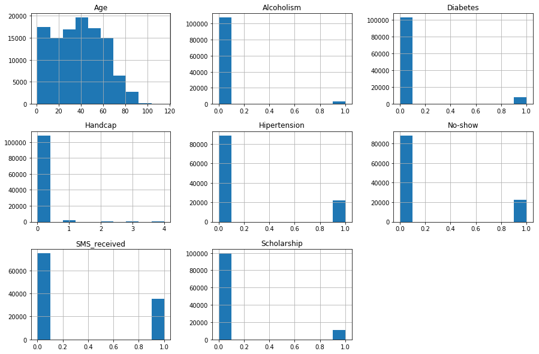

```python
df.hist(figsize=(15, 10));
```

Above histogram graphs show the following:

- Most patients are with age between 0 and 70.
- Most patients aren't with a specific one type of disease (such as diabetes, hypertension, etc..).
- The majority of patients show up for their appointments (around 90,000 out of the 110,000) while the minority don't show up for their appointments (around 20,000).
- Most of the patients did't recieve SMS.
- Most patients don't have scholarship

Now we will start comparing the different characteristics of patients who showed up and the ones didn't to find out what may correlate with that.

```python
# creating two masks for showing and not showing up
showed_up = df['No-show'] == 0
no_show = df['No-show'] == 1
```

```python
df[showed_up].mean()
```

```
Age             39.009861
Scholarship      0.093903
Hipertension     0.204392
Diabetes         0.073837
Alcoholism       0.030417
Handcap          0.022742
SMS_received     0.291334
No-show          0.000000
dtype: float64
```

```python
df[no_show].mean()
```

```
Age             35.379533
Scholarship      0.115507
Hipertension     0.169004
Diabetes         0.064071
Alcoholism       0.030333
Handcap          0.020297
SMS_received     0.438371
No-show          1.000000
dtype: float64
```

The above mean values for columns of the two diffrent groups suggest the following (more investigation will be done):

- Mean age of the patients who showed up tend to be slightly more than the age of the patients who didn't
- Scholership, hypertension, diabetes, alcoholism and being handicapped seem not to or have a very small effect on patients showing up
- SMS received seem to have negative correlation with showing up

Making a function that plot a bar chart based on the groupby vs. a specific factor since we will use it multiple times.

```python
def groupby_barchart(grby, fctr):
    df.groupby(grby)[fctr].mean().plot(kind='bar', grid=True);
```

Starting with SMS received, lets find out how showing up is correlated with SMS received

[figure not shown]

```python
groupby_barchart('No-show', 'SMS_received')
plt.ylabel('Received SMS mean (%)')
plt.xlabel('Showing up')
plt.title('Paitents recieved SMS mean vs. showing up')
ax = plt.gca()
ax.set_xticks([0,1])
ax.set_xticklabels(['No show', 'Show']);
```

```python
(df[no_show].SMS_received.mean(), df[showed_up].SMS_received.mean())
```

```
(0.43837089475334917, 0.29133411935425357)
```

The above bar chart shows that 29% of patients that showed up for their appointments have received SMS and 44% of patients that didn't show up for their appointments have also received SMS, meaning received SMS doesn't contribute positivly in making patients show up for appointments.

Next, we will see how showing up is correlated with age

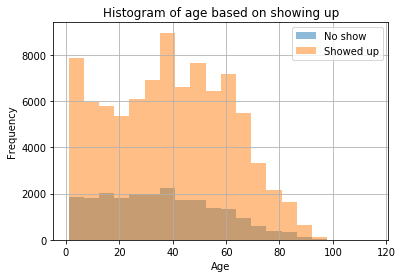

```python
df.Age[no_show].hist(label='No show', alpha=0.5, bins=20)
df.Age[showed_up].hist(label='Showed up', alpha=0.5, bins=20)
plt.ylabel('Frequency')
plt.xlabel('Age')
plt.title('Histogram of age based on showing up')
plt.legend();
```

```python
(df[no_show].Age.mean(), df[showed_up].Age.mean())
```

```
(35.379532712993239, 39.00986105668683)
```

Patients that didn't show up seem to be younger, with an average of 35 years old, and the ones who actually showed up are with average of 39 years old, which means in general the age seem to affect patients showing up.

Next, we wills see how showing up is correlated with gender

```
Gender
F    0.203146
M    0.199679
Name: No-show, dtype: float64
```

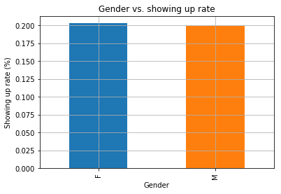

```python
groupby_barchart('Gender', 'No-show')
plt.ylabel('Showing up rate (%)')
plt.xlabel('Gender')
plt.title('Gender vs. showing up rate')
df.groupby('Gender')['No-show'].mean()
```

```python
df.groupby('Gender').Age.count() # age doesn't make a difference, we just want the count
```

```
Gender
F    71840
M    38687
Name: Age, dtype: int64
```

Females seems to get ill more in general but both genders seem not to show for their appointments at the same rate, meaining gender doesn't affect patients showing up.

Next, we will see whether the gap between the scheduled day and the appointment day affect patients showing up for their appointments.

Geetting the difference between the scheduled day and the appointment day as number of days and putting it in a new column

```python
df['ScheduledDay'] = pd.to_datetime(df['ScheduledDay'])
df['AppointmentDay'] = pd.to_datetime(df['AppointmentDay'])
df['days_in_between'] = (df['AppointmentDay'].dt.date - df['ScheduledDay'].dt.date)

df['days_in_between'] = df['days_in_between'].apply(lambda date: date.days)
df.head(10)
```

|  | Gender | ScheduledDay | AppointmentDay | Age | Neighbourhood | Scholarship | Hipertension | Diabetes | Alcoholism | Handcap | SMS_received | No-show | days_in_between |
| --- | --- | --- | --- | --- | --- | --- | --- | --- | --- | --- | --- | --- | --- |
| 0 | F | 2016-04-29 18:38:08 | 2016-04-29 | 62.0 | JARDIM DA PENHA | 0 | 1 | 0 | 0 | 0 | 0 | 0 | 0 |
| 1 | M | 2016-04-29 16:08:27 | 2016-04-29 | 56.0 | JARDIM DA PENHA | 0 | 0 | 0 | 0 | 0 | 0 | 0 | 0 |
| 2 | F | 2016-04-29 16:19:04 | 2016-04-29 | 62.0 | MATA DA PRAIA | 0 | 0 | 0 | 0 | 0 | 0 | 0 | 0 |
| 3 | F | 2016-04-29 17:29:31 | 2016-04-29 | 8.0 | PONTAL DE CAMBURI | 0 | 0 | 0 | 0 | 0 | 0 | 0 | 0 |
| 4 | F | 2016-04-29 16:07:23 | 2016-04-29 | 56.0 | JARDIM DA PENHA | 0 | 1 | 1 | 0 | 0 | 0 | 0 | 0 |
| 5 | F | 2016-04-27 08:36:51 | 2016-04-29 | 76.0 | REPÚBLICA | 0 | 1 | 0 | 0 | 0 | 0 | 0 | 2 |
| 6 | F | 2016-04-27 15:05:12 | 2016-04-29 | 23.0 | GOIABEIRAS | 0 | 0 | 0 | 0 | 0 | 0 | 1 | 2 |
| 7 | F | 2016-04-27 15:39:58 | 2016-04-29 | 39.0 | GOIABEIRAS | 0 | 0 | 0 | 0 | 0 | 0 | 1 | 2 |
| 8 | F | 2016-04-29 08:02:16 | 2016-04-29 | 21.0 | ANDORINHAS | 0 | 0 | 0 | 0 | 0 | 0 | 0 | 0 |
| 9 | F | 2016-04-27 12:48:25 | 2016-04-29 | 19.0 | CONQUISTA | 0 | 0 | 0 | 0 | 0 | 0 | 0 | 2 |

```
(15.83148886598862, 8.7546594413205145)
```

[figure not shown]

```python
groupby_barchart('No-show', 'days_in_between')
plt.ylabel('Days gap mean (%)')
plt.xlabel('Showing up')
plt.title('Days gap mean vs. showing up')
ax = plt.gca()
ax.set_xticks([0,1])
ax.set_xticklabels(['No show', 'Show'])

(df[no_show].days_in_between.mean(), df[showed_up].days_in_between.mean())
```

Next, we will see how showing up is correlated with neighbourhood

```
Text(0.5,1,'Neighbourhoods vs. Showing up rate')
```

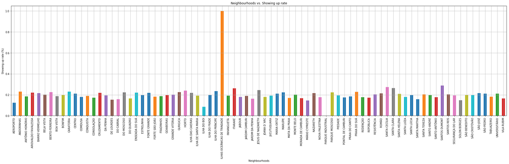

```python
df.groupby('Neighbourhood')['No-show'].mean().plot(kind='bar', figsize=(35, 8), grid=True);
plt.ylabel('Showing up rate (%)')
plt.xlabel('Neighbourhoods')
plt.title('Neighbourhoods vs. Showing up rate')
```

```
Text(0.5,1,'Neighbourhoods vs. Frequency')
```

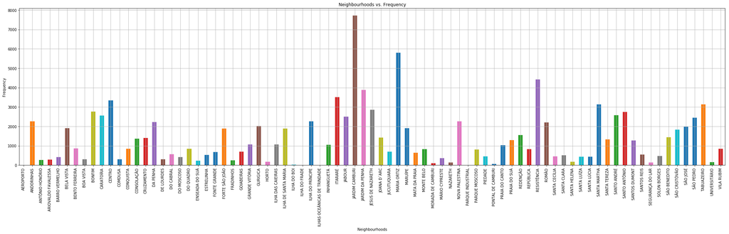

```python
df.groupby('Neighbourhood')['No-show'].count().plot(kind='bar', figsize=(35, 8), grid=True);
plt.ylabel('Frequency')
plt.xlabel('Neighbourhoods')
plt.title('Neighbourhoods vs. Frequency')
```

As we can see, the ones that seem to be off are having so little recods which made the showing up rates either 0 or 1.

Overall, it seems like the neighbourhoods does not affect the patients showing up.

## Conclusions

The investigation found that, to answer the main posed question of what factors are important in order to predict if a patient will show up for their scheduled appointment, the factors that are likely to be affecting patients showing up are the following:

- The gap between the scheduled day and the appointment day affect patients showing up for their appointments.
- The age of patients (specifically, younger patients are more likely not to show up compared to older patients)

To investigate these findings further, additional analysis could be undertaken, like for example finding the correlation between columns themselves rather than comparing them to independent variable (i.e. the No-show column) and so on.

```python
from subprocess import call
call(['python', '-m', 'nbconvert', 'investigate-a-dataset.ipynb'])
```

```
0
```